# Graphics Walkthrough for FRSC

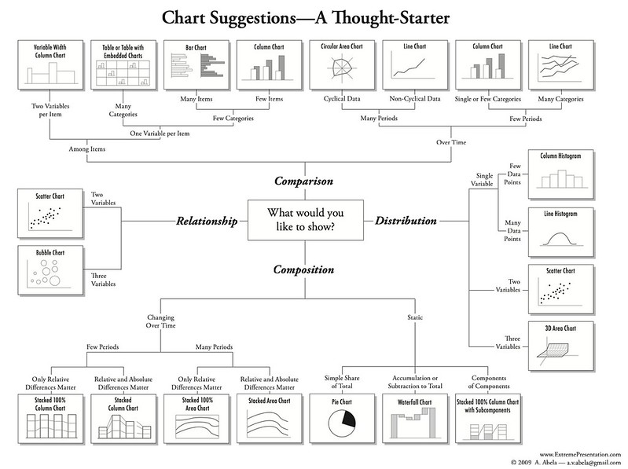

# The Data

Here i am going to use some example data that we have from the Rice Rivers Center that has been collected from a series of instruments on site. These include both atmospheric and aquatic data types.

I have put this into a function in the next chunck of code. You should be able to look at the code and follow the logic. The data are read in from a google sheet, textual representation of date and time for each record are turned into actual date object that spin off Day, Weekday, & Month objects. I also convert a bunch of the data types into standard measurements and keep a subset of the measurements.

Let’s look at the data.

```
      Date                          Month           Day            Weekday
 Min.   :2014-01-01 00:00:00   January :2976   Min.   : 1.0   Saturday :1152
 1st Qu.:2014-01-22 08:22:30   February:2688   1st Qu.: 8.0   Sunday   :1152
 Median :2014-02-12 16:45:00   March   :2535   Median :15.0   Monday   :1152
 Mean   :2014-02-12 16:45:00                   Mean   :14.8   Tuesday  :1152
 3rd Qu.:2014-03-06 01:07:30                   3rd Qu.:22.0   Wednesday:1248
 Max.   :2014-03-27 09:30:00                   Max.   :31.0   Thursday :1191
                                                              Friday   :1152
 Air_Temperature         Rain           Wind_Speed     Wind_Direction
 Min.   :-15.6950   Min.   :0.00000   Min.   : 0.000   Min.   :  0.00
 1st Qu.: -0.2528   1st Qu.:0.00000   1st Qu.: 3.947   1st Qu.: 37.31
 Median :  3.0222   Median :0.00000   Median : 6.544   Median :137.30
 Mean   :  3.7751   Mean   :0.02137   Mean   : 8.713   Mean   :146.20
 3rd Qu.:  8.0056   3rd Qu.:0.00000   3rd Qu.:11.666   3rd Qu.:249.95
 Max.   : 23.8167   Max.   :8.81380   Max.   :49.040   Max.   :360.00

    Humidity     Barametric_Pressure      PAR           Water_Temperature
 Min.   :15.37   Min.   :29.11       Min.   :   0.000   Min.   :-0.140
 1st Qu.:42.25   1st Qu.:29.87       1st Qu.:   0.000   1st Qu.: 3.930
 Median :56.40   Median :30.01       Median :   0.046   Median : 5.450
 Mean   :58.37   Mean   :30.02       Mean   : 241.984   Mean   : 5.529
 3rd Qu.:76.59   3rd Qu.:30.21       3rd Qu.: 337.900   3rd Qu.: 7.410
 Max.   :93.00   Max.   :30.58       Max.   :1957.000   Max.   :13.300
                                                        NA's   :1
  Water_Depth       Salinity            pH         Turbidity
 Min.   :3.705   Min.   :0.0000   Min.   :6.43   Min.   :  6.20
 1st Qu.:4.451   1st Qu.:0.0700   1st Qu.:7.50   1st Qu.: 15.50
 Median :4.684   Median :0.0800   Median :7.58   Median : 21.80
 Mean   :4.677   Mean   :0.0759   Mean   :7.60   Mean   : 24.54
 3rd Qu.:4.913   3rd Qu.:0.0800   3rd Qu.:7.69   3rd Qu.: 30.30
 Max.   :5.454   Max.   :0.1000   Max.   :9.00   Max.   :187.70
                 NA's   :1        NA's   :1      NA's   :1
   Chlorophyl         ODO
 Min.   :  1.3   Min.   : 87.5
 1st Qu.:  3.7   1st Qu.: 99.2
 Median :  6.7   Median :101.8
 Mean   :137.3   Mean   :102.0
 3rd Qu.:302.6   3rd Qu.:104.1
 Max.   :330.1   Max.   :120.8
 NA's   :1       NA's   :1
```

Let’s now filter the data for just the first five days of records that were collected in `February` and name the data.frame `df`.

# Distribution

The histogram is the most basic type of data display. Create a historgram of `Air_Temperature`.

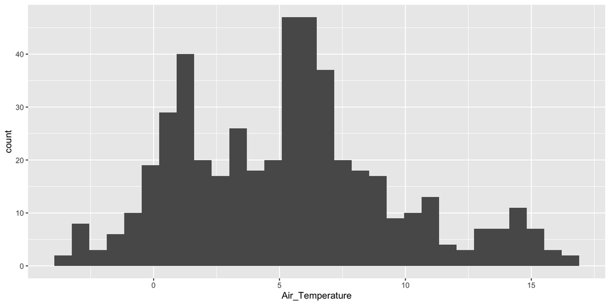

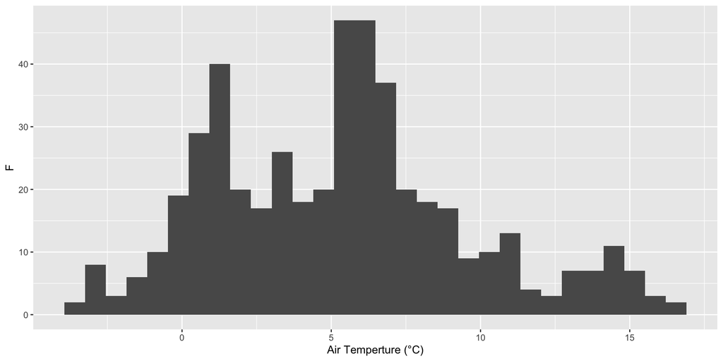

Let’s change some colors.  
- The `color` option in the `geom_histogram()` function references the lines around the bar.  
- The `fill` option references the color of the bar.

Add these to the `geom_histogram()` with the colors of your choosing.

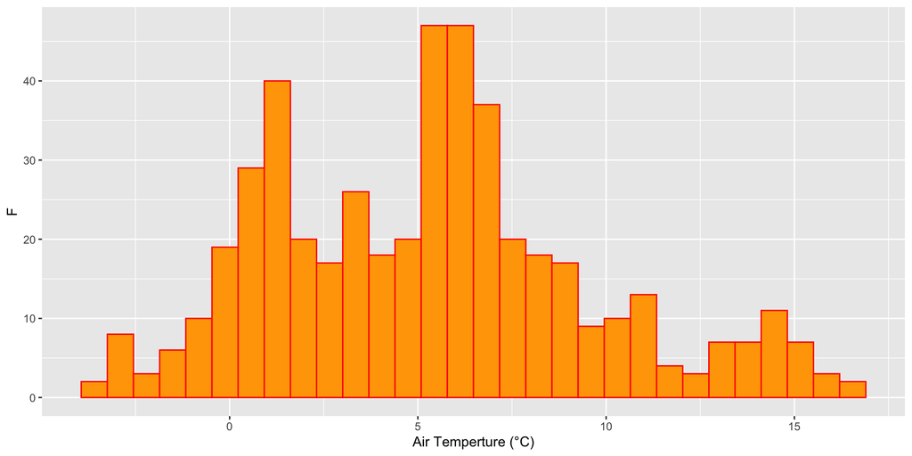

### “You Are My Density”

A `density` plot is the next level as it estimates the continuous distribution of values.

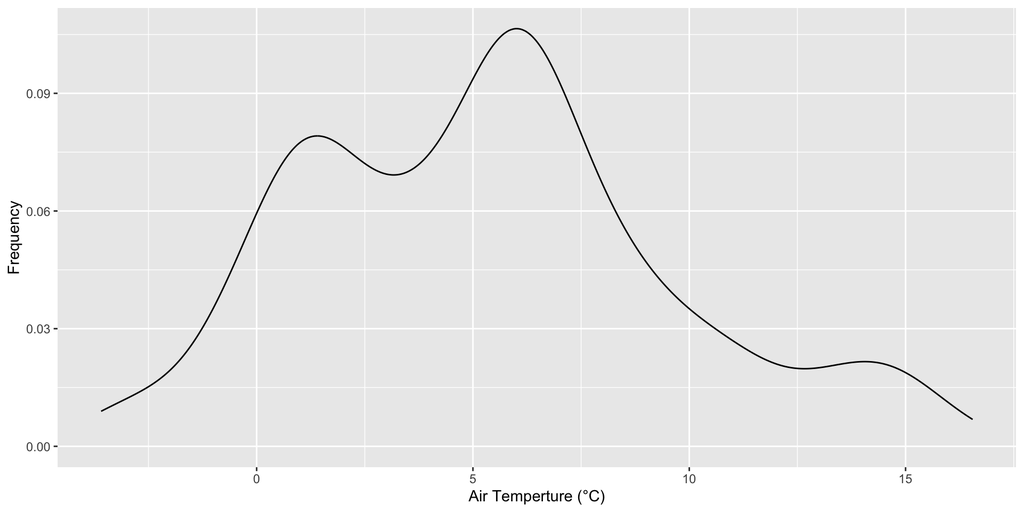

Let’s adjust the `fill` and `color` of this one as well.

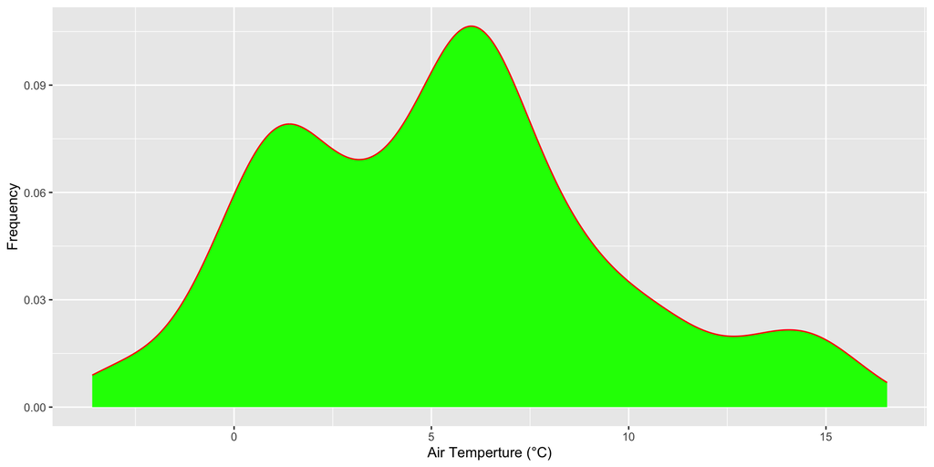

# Relationship

OK, let’s look at some plots with 2-variables. Here we can start with two continuous varibles, `Air_Temperature` and `Water_Temperature`.

### The Scatter Plot

Make a scatter plot of these two variables, with `Air_Temperature` on the X-Axis and `Water_Temperature` on the Y-Axis. Label the axes appropriately.

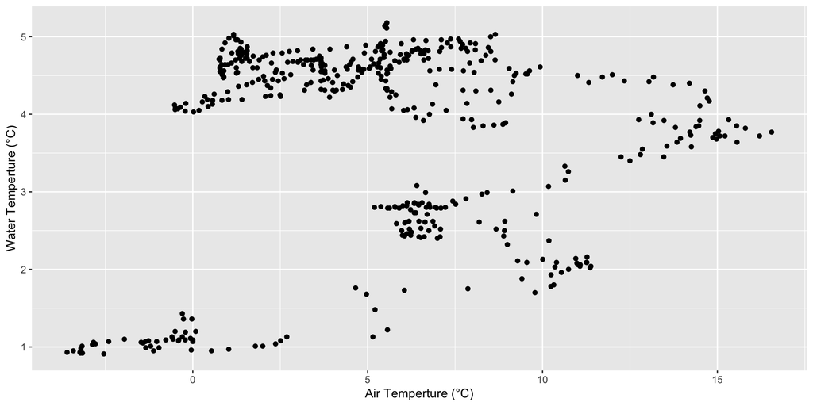

### Symbology

You can use the plot shape and a second column of data to change the symbols. For this, it should be a `categorical` variable and must be part of the `aes().` Contrast this to the `fill` and `color` examples used above, which were put outside the `aes()` call and are not based upon something **inside** the data.frame.

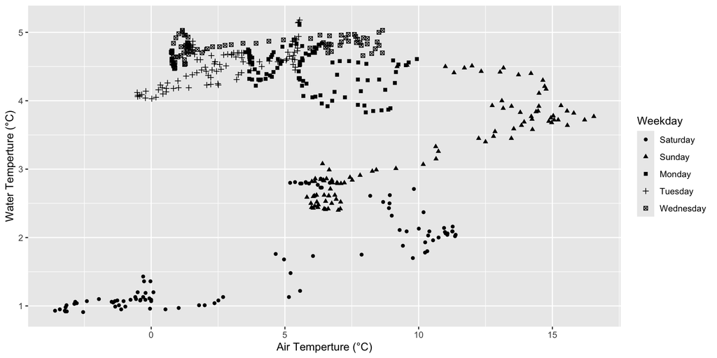

### Color

Just like the shape, color can be defined by some other variable in the data itself—also specified within the `aes()` function. This time, let’s use *Photosynthetically Active Radiation* (PAR) to indicate the color of the points above. Keep the symbols as well.

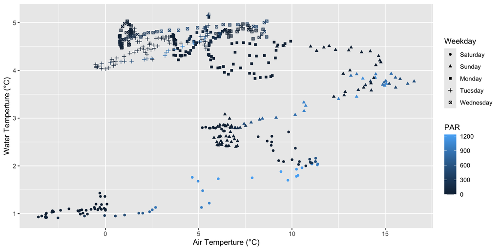

# Comparison

For categorical data as a predictor and a continuous variable at as the response, we can use several different types of plots. I’ll start with some easy ones.

## Box Plots

A boxplot is a very *data-rich* display. I thas the median (the horizontal line), the inner 50% percentile (the box), the 95%th percentile (whiskers), and any potential outliers. Use `Weekday` as the predictor and `Air_Temperture` as the response.

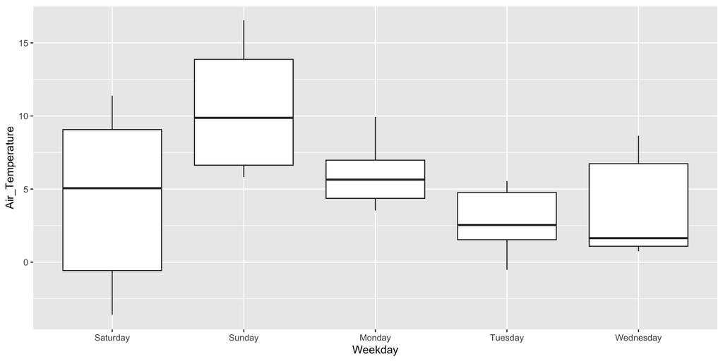

Add `notch=TRUE` to the `geom_boxplot()`. What does that show?

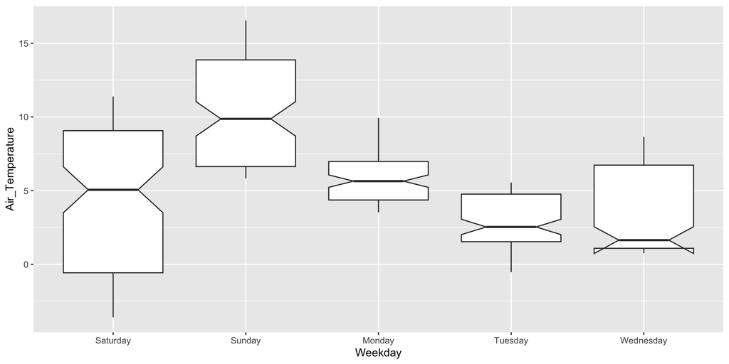

Another variant of this is provided by the `geom_violin()` geometry. This gives the the density of the continuous variable rather than just the quantiles.

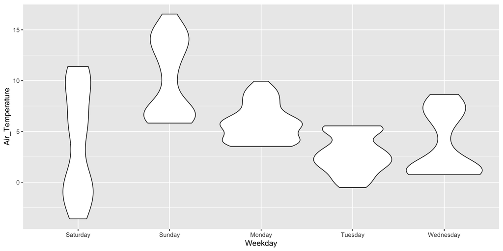

## Bar Plot

A `geom_bar()` plot will take data and *tally* it to determine the height of the bar itself. In our example, we can use this to depict the nubmer of records per day whose temperature was above freezing but below 10°C.

1. Filter the data for `Air_Temperature` > 0 & `Air_Temperature` < 10.
2. Use `geom_bar()` to tally `Weekday`.

The `geom_bar()` height for each will the the number of elements for each `Weekday`. Notice how the `aes()` only has one variable specified, the x-variable.

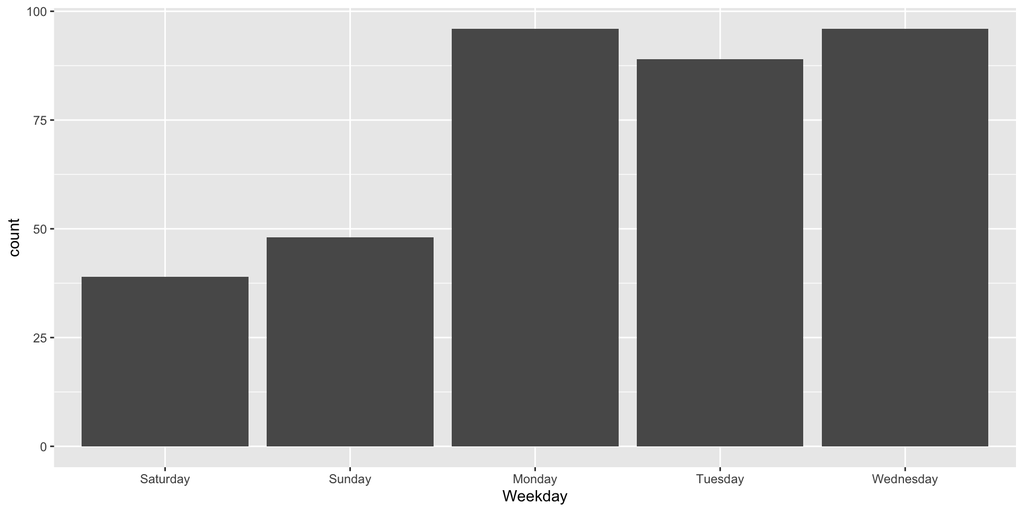

## Column Plot

A `geom_col()` plot is one where you can specify the the x-axis and y-axis values for the bars. Here is an example where I find the highest temperature for each day using `group_by()` and `summarize()` to make a new data.frame. Do this to show the output data.frame with a column for Weekday and one for the maximum air temperature.

```
# A tibble: 5 × 2
  Weekday   Maximum
  <ord>       <dbl>
1 Saturday    11.4
2 Sunday      16.5
3 Monday       9.93
4 Tuesday      5.55
5 Wednesday    8.65
```

Create a `geom_col()` for these data. Note, the `aes()` references the names of the columns in the data.frame that exits from the `group_by() |> summarize()` translation.

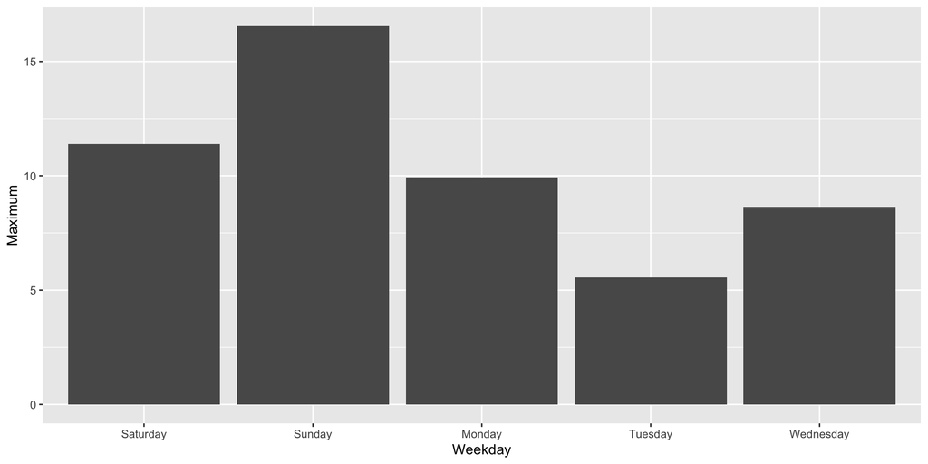

## Line Chart

A `geom_line()` provides a single (or duplicate) display of data. Use `Date` and `Air_Temperature`

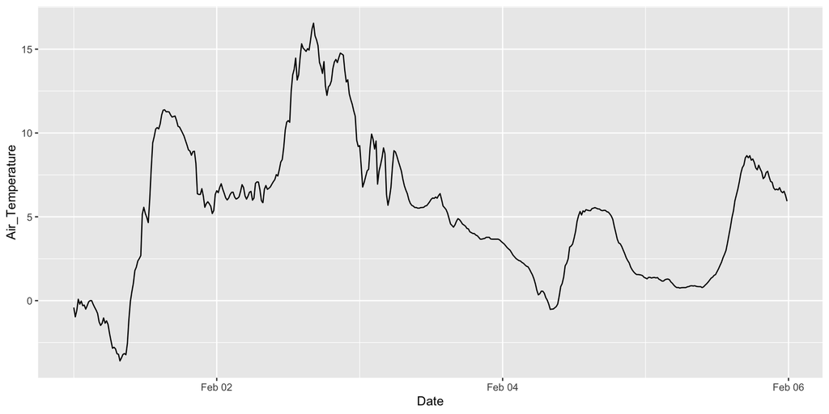

For linear data, you can add more than one `geom_line()` object. Create a graph that has `Air_Temperature` and `Water_Temperature` plot through time. To make it easier, put the `aes()` inside each of the `geom_line()` calls and assign different colors for each (outside the `aes()`).

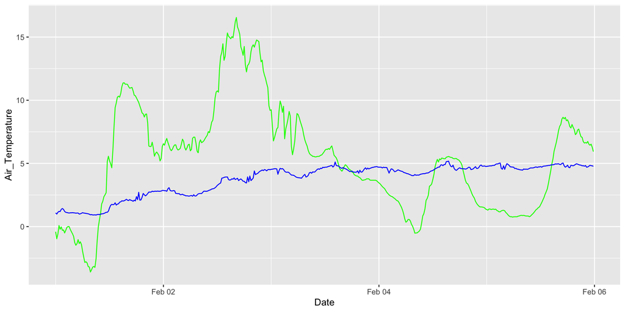